# Analiza danych z CNK z maja 2012

Przemysław Dycha, Magda Sobiczewska, Krzysztof Smutek, Piotr Weremczuk

20 kwiecień 2016

# Faza I

## Wprowadzenie

Na samym początku interesują nas podstawowe statystyki dotyczące eksponatów:

- liczba odwiedzających w poszczególnych dniach tygodniach
- liczba odwiedzających w zależności od godziny odwiedzin
- czas spędzony na odwiedzaniu wszystkich eksponatów przez odwiedzającego
- liczba odwiedzających poszczególne stacje
- średni czas spędzony na danej stacji

## Obróbka danych i metody pracy

W poniższej analizie organiczyliśmy się do maja. Z danych wyrzuciliśmy również użytkowników oznaczonych -1. Z powyższych danych szukaliśmy odpowiedzi na nasze pytania korzystając z biblioteki sqldf. Obcięliśmy również odwiedzających do takich, którzy spędzili na poszczególnych eksponatach nie więcej niż godzinę.

## Otrzymane wyniki

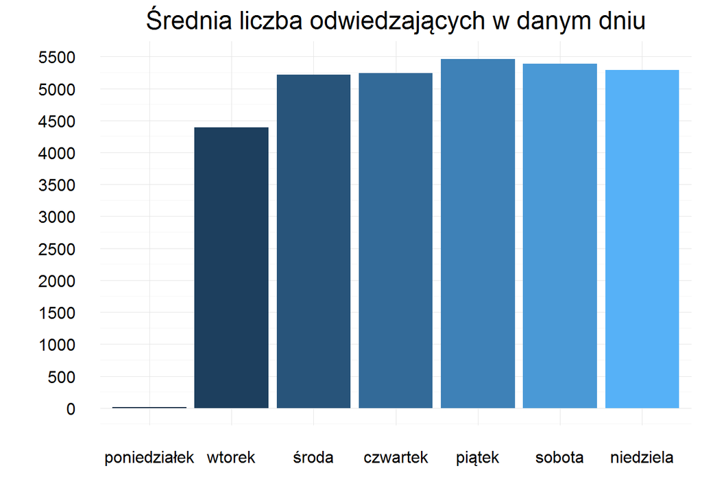

Zauważamy, że w poniedziałek liczba odwiedzjących jest bliska 0. Wynika to z faktu, że CNK w tym dniu jest zamknięte. Pomimo tego można zauważyć znikome interakcje , gdyż w tym czasie są wykonywane prace konserwacyjne na eksponatach. Ponadto liczba odwiedzających w poszczególne dni jest zbliżona. Na mniejszą liczbę we wtorek od pozostałych dni miał najprawdopodobniej wpływ 1 maja, który w 2012 roku wypadł we wtorek.

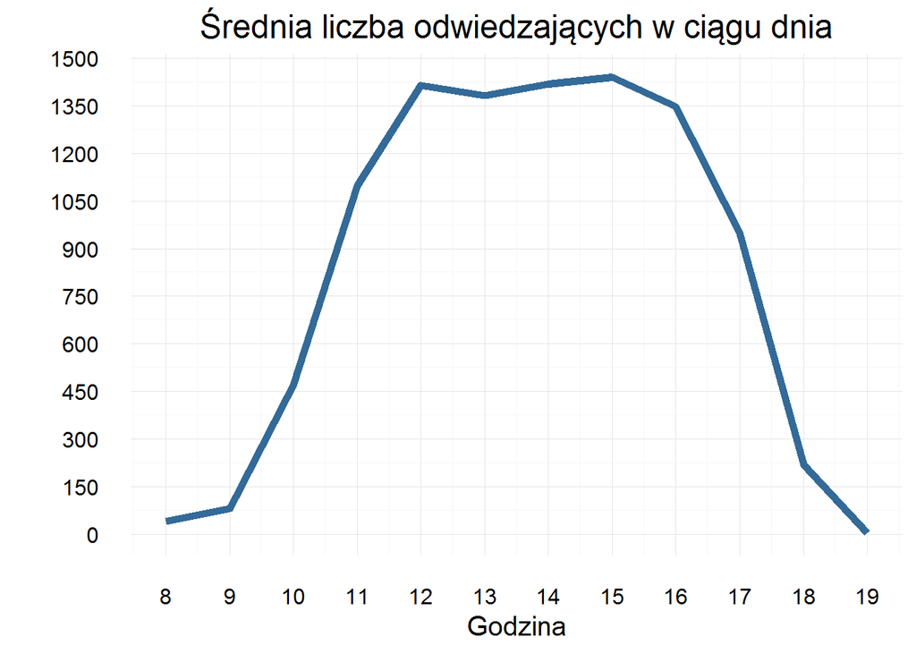

Zauważamy, że największa liczba odwiedzających centrum jest w godzinach 11-15. W późniejszych i wcześniejszych godzinach aktywność jest dużo mniejsza. Może być to przydatna informacja dla osób, które chcą spokojnie odwiedzić dużą liczbę eksponatów.

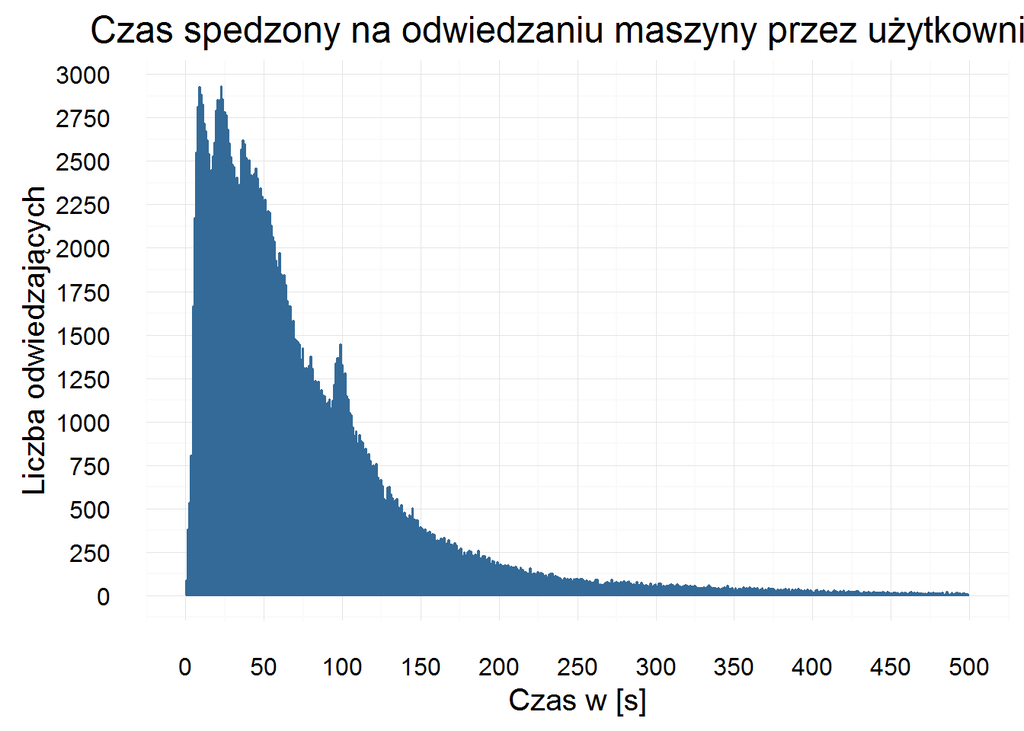

Większość odwiedzających spędza na danym eksponacie niewielką liczbę czasu. Jednak w okolicach 100s można zauważyć wzrastający pik. Oznacza to, że spora grupa ludzi zainteresowanych danym eksponatem przeznacza na jego odwiedzenie właśnie taki czas.

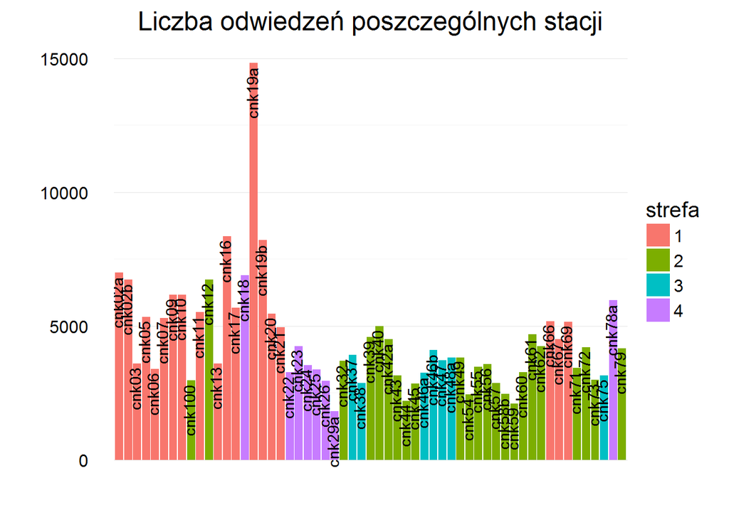

Zauważamy, że najbardziej odwiedzaną stacją było Wejście do Sali strachów-(cnk19a) oraz Wyjście z Sali strachów-(cnk19b) (jest to zapewne jeden eksponat rozbijający moment wejścia i wyjścia na osobne eksponaty). Jak również Powąchaj mnie-(cnk16), Mózg podczas pracy-(cnk 02) czy Kim jesteś-(cnk18). Najmniej odwiedzanym eksponatem był Robot portrecista-(cnk29a). Wpływ na niską liczbę odwiedzających miał zapewne długi czas spędzany przy eksponacie.

Ponadto dokonaliśmy podziału na stacje tematyczne cnk w sposób następujący

- Strefa 1: JA
- Strefa 2: JA - MY-ONI
- Strefa 3: JA -ŚWIAT
- Strefa 4: JA - TY

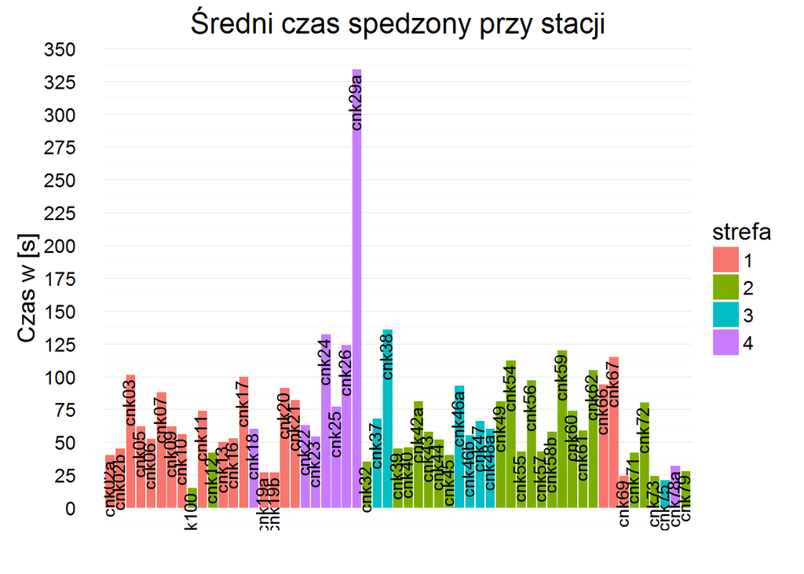

Tak jak przypuszczaliśmy stacja Robot portrecista-(cnk29a) miała największy czas spędzany na eksponacie. Niewielka liczba odwiedzających wynika z tego, że jest ona bardzo często zajęta. Być może warto byłoby utworzyć nowy eksponat o podobnej charakterystyce.

## Wnioski początkowe

Zauważyliśmy, że czasy interakcji z eksponatami są w większości przypadków bardzo krótkie. W poszczególne dni tygodnia średnia liczba odwiedzin jest podobna, zaś czas odwiedzin jest skupiony w okolicach południa.

Ponadto po podzieleniu na grupy tematyczne CNK zauważyliśmy, że największe spędzone czasy średnie przy stacji występują dla grupy JA-TY, a najmniejsze dla grupy JA. Wynika to najprawdopodopniej z faktu, że na początku każdy chce obejrzeć jak największą liczbę stacji, dlatego wykonuje wiele krótkich interakcji. Dopiero po pewnym czasie następuje wyszukiwanie interesujących dla siebie eksponatów przy których użytkownik spędza więcej czasu. Warto ten fakt wykorzystać ustawiając najmniej interesujące stacje na początku, by zwiększyć liczbę ich odwiedzin.

# Faza II i III - analiza segmentów

## Co chcemy zrobić ?

W drugim etapie podzielimy odwiedzających na segmenty i postaramy się odpowiedzieć na pytanie w jaki sposób wydziellić grupy charaktarestycznych odwiedzających. Czy można je w jakiś sposób scharakteryzować?

## Wybrane podziały

Postaramy się odpowiedzieć na następujące pytania:

- jak wygląda podział stacji ze względu na czas spędzony na stacji, czy ma on jakiś związek z podziałem tematycznym CNK
- jak wygląda zależność między liczbą interakcji użytkownika, a czasem spędzonym na stacjach
- jak wygląda podział ze względu na liczby odwiedzonych stacji, a czasem spędzonym na stacjach

## Zastosowane metody:

W wyniku na dużą liczbę danych, odwiedzający zostali podzieleni na podstawie algorytmu kmeans. Ograniczenia pamięciowe nie pozwoliły na policzenie potrzebnych odległości w inny sposób. Dokonaliśmy również podziału na sesje, który wyróżnia odwiedzającego powracającego do eksponatu po pewnym czasie.

## Uzyskane rezulaty

### Średni czas a liczba odwiedzających

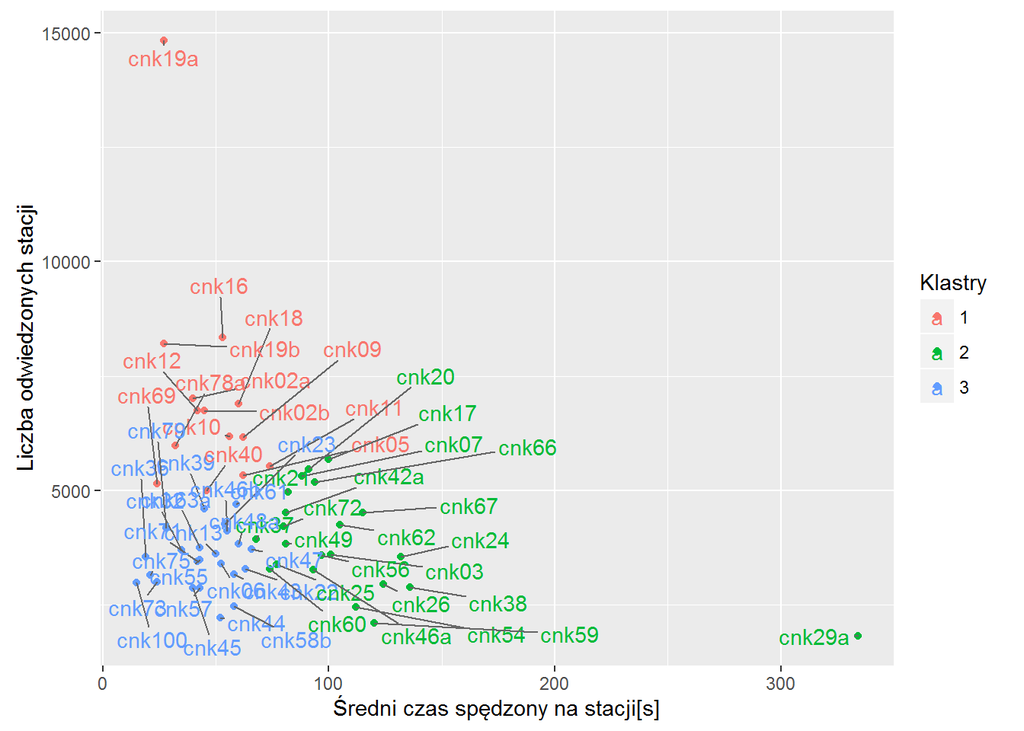

Na tym wykresie widać jak rozkładały się grupy w zależności od czasu oraz liczby odwiedzających. Powstały trzy charakterystyczne grupy. Pierwsza grupa to grupa w której liczba odwiedzających jest największa. Jak widzimy czas spędzony przy maszynie nie jest długi, mimo to maszyna przyciąga dużą grupę ludzi.W drugiej grupie znajdują się zaś eksponaty dla których średni czas jest długi i przekracza minutę.W ostatniej grupie znalazły się mało interesujące eksponaty dla których mamy niewielką liczbę odwiedzających spędzającą na nich mało czasu.

Potwierdzają to boxploty z uzyskanych grup

```
##    station numberOfVisitors mediantime
## 2   cnk02b             6741         45
## 43   cnk56             3581         97
## 42   cnk55             3479         43
```

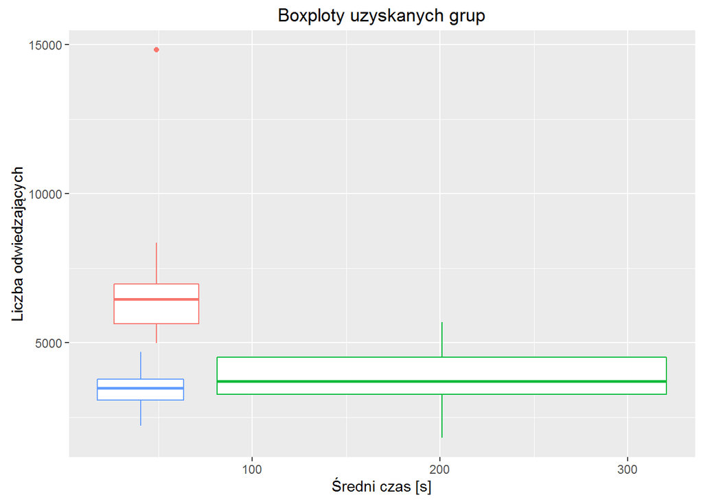

Przywołując wykres z podziałami tematycznymi zauważamy, że grupę czerwoną (krótki czas, duża liczba odwiedzin) tworzą przede wszystkim eksponaty z kategorii JA. Potwierdza to zauważone na wcześniejszych wykresach zależności.

### Podział ze względu na liczbę odwiedzonych stacji

Na samym początku utworzyliśmy macierz w której zawarte są informacje dotyczące odwiedzającego. Dokładniej:

- liczby wejść na danej stacji przez odwiedzającego
- łączna liczba czynności na wszystkich eksponatach
- średni czas spędzony na wszystkich odwiedzonych stacjach
- liczba odwiedzonych stacji

Korzystając z tej charakteryzacji dokonaliśmy dwóch podziałów: zależności czasu spędzonego od liczby interakcji oraz liczby odwiedzonych stacji w zależności od średniego czasu spędzonego na stacji. Poniżej przedstawiamy fragment macierzy oraz uzyskane rezultaty:

```
##   visitor cnk02a cnk02b cnk03 cnk05 cnk75 cnk78a cnk79 interacton_count
## 1 1043614      0      0     0     0     0      0     0               15
## 2 1043616      0      0     0     0     0      0     0                1
## 3 1043617      0      0     0     0     0      0     0               34
## 4 1043631      0      0     0     0     0      0     0               38
## 5 1043636      4      3     4     4     3      0     3              141
## 6 1043637      0      0     0     0     0      0     3               53
##   average_time total_sessions
## 1    110.00000              3
## 2     14.00000              1
## 3    250.75000              3
## 4     62.75000              8
## 5     93.20833             25
## 6    197.20000              5
```

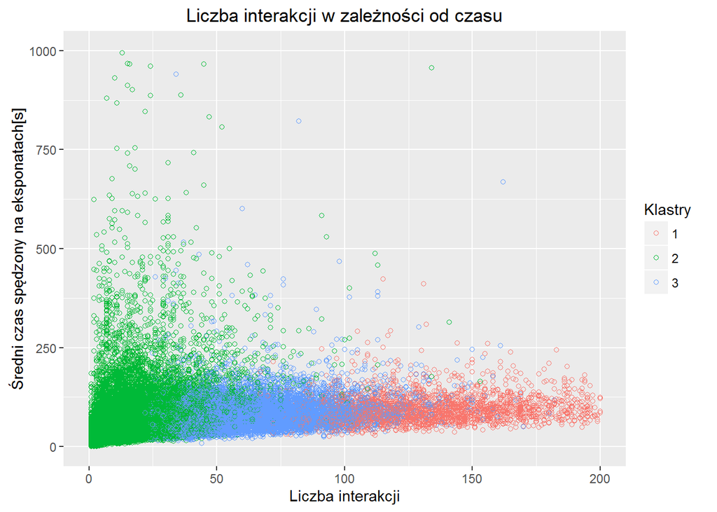

Widzimy 3 charakterystyczne grupy. Jedna z nich jest przeważająca. Są to ci odwiedzający, którzy wynonali niewielką liczbę czynności i niewielką ilość czasu spędzili na aktywne zwiedzanie eksponatów.

Podzielmy teraz odwiedzających na grupy w zależności od liczby odwiedzonych eksponatów i średniego czasu spędzonego na stacjach.

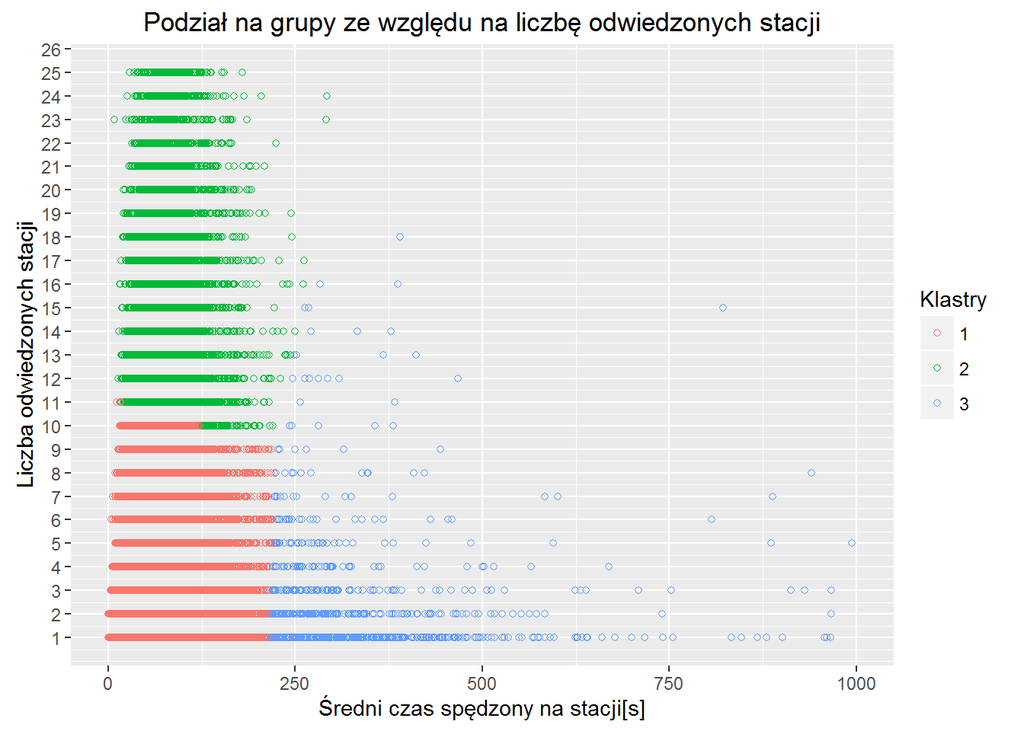

```
##   cluster count(*)
## 1       1    26393
## 2       2     9303
## 3       3      811
```

Do podziału wykorzystaliśmy klasteryzację z algorytmu kmeans. Utworzyliśmy 3 klastry. Patrząc na wykres oraz statystyki grupy zauważamy: grupę w której znajdują się osoby odwiedzające niewielką liczbę eksponatów i spędzające na nich niewielką ilość czasu. W kolejnej znajdują się osoby, które spędziły więcej czasu na poszczególnych eksponatach. Ostatnia przedstawia zaś osoby, które odwiedziły dużą grupę eksponatów.